# F01 Supplement — Mixed-Model Report

Phenotype divergence, HR vs LR

Author

A_HRvLR_2026

Published

July 10, 2026

## Overview

This report fits one linear mixed model per phenotype, reports each fit, and checks its assumptions. The stack is small: `lmerTest` fits the models, `easystats` (`parameters`, `performance`) makes the tables and diagnostics, and `emmeans` gives the contrast. Every number traces back to `00_input/HRvLR_meta.csv`.

```r
pacman::p_load(here, dplyr, parameters, performance, emmeans, purrr, knitr)
source(here("04_Figures", "F01", "a_script", "functions", "build.R"))

meta <- f01_meta()
fits <- lmm_models(meta) # one lmer per outcome, named by phenotype
names(fits)
```

```
[1] "mCSA"          "fCSA Mixed"    "fCSA Type I"   "fCSA Type II"
[5] "1RM Leg Press" "1RM Extension"
```

Six models, one per phenotype: whole-muscle CSA, three fibre-CSA measures, and two strength tests.

## The model

Each subject is measured at T1 and T2, so the two readings are correlated. The model gives every subject its own intercept ($u_i$) and estimates the group, time, and interaction effects as fixed:

$$y_{ij} = \beta_0 + \beta_1\,\text{Group}_i + \beta_2\,\text{Time}_j + \beta_3\,(\text{Group}\times\text{Time})_{ij} + u_i + \varepsilon_{ij}$$

The `Group × Timepoint` interaction is the divergence: whether training moves HR and LR by different amounts. A random slope on Time is not identifiable with two timepoints per subject, so the model uses a random intercept only, fitted by REML with Satterthwaite degrees of freedom.

## Coefficients

`parameters::model_parameters` returns each model’s fixed effects with confidence intervals and Satterthwaite df. The interaction row (`GroupLR:TimepointT2`) is the test; below zero means LR gains less than HR.

```r
coef_tbl <- imap_dfr(fits, function(fit, measure) {
  model_parameters(fit, effects = "fixed") |>
    as.data.frame() |>
    transmute(measure,
      term = Parameter, estimate = Coefficient,
      SE, CI_low, CI_high, df = df_error, p
    )
})
kable(coef_tbl, digits = 3, caption = "Fixed-effect coefficients (REML, Satterthwaite df)")
```

Fixed-effect coefficients (REML, Satterthwaite df)

| measure | term | estimate | SE | CI_low | CI_high | df | p |
| --- | --- | --- | --- | --- | --- | --- | --- |
| mCSA | (Intercept) | 26.220 | 1.990 | 22.129 | 30.311 | 26 | 0.000 |
| mCSA | GroupLR | 1.105 | 2.814 | -4.680 | 6.890 | 26 | 0.698 |
| mCSA | TimepointT2 | 3.013 | 0.576 | 1.829 | 4.196 | 26 | 0.000 |
| mCSA | GroupLR:TimepointT2 | -1.871 | 0.814 | -3.545 | -0.198 | 26 | 0.030 |
| fCSA Mixed | (Intercept) | 5831.693 | 515.732 | 4771.591 | 6891.794 | 26 | 0.000 |
| fCSA Mixed | GroupLR | 795.871 | 729.355 | -703.339 | 2295.081 | 26 | 0.285 |
| fCSA Mixed | TimepointT2 | 914.046 | 344.125 | 206.687 | 1621.405 | 26 | 0.013 |
| fCSA Mixed | GroupLR:TimepointT2 | -1875.969 | 486.666 | -2876.325 | -875.612 | 26 | 0.001 |
| fCSA Type I | (Intercept) | 5328.415 | 451.880 | 4399.563 | 6257.267 | 26 | 0.000 |
| fCSA Type I | GroupLR | 1275.721 | 639.054 | -37.874 | 2589.316 | 26 | 0.056 |
| fCSA Type I | TimepointT2 | 889.552 | 341.655 | 187.270 | 1591.835 | 26 | 0.015 |
| fCSA Type I | GroupLR:TimepointT2 | -2081.390 | 483.174 | -3074.568 | -1088.212 | 26 | 0.000 |
| fCSA Type II | (Intercept) | 6045.545 | 613.680 | 4784.108 | 7306.982 | 26 | 0.000 |
| fCSA Type II | GroupLR | 622.609 | 867.874 | -1161.332 | 2406.550 | 26 | 0.480 |
| fCSA Type II | TimepointT2 | 1043.169 | 325.898 | 373.276 | 1713.061 | 26 | 0.004 |
| fCSA Type II | GroupLR:TimepointT2 | -1914.120 | 460.889 | -2861.491 | -966.749 | 26 | 0.000 |
| 1RM Leg Press | (Intercept) | 143.625 | 17.773 | 107.093 | 180.157 | 26 | 0.000 |
| 1RM Leg Press | GroupLR | -13.250 | 25.134 | -64.914 | 38.414 | 26 | 0.603 |
| 1RM Leg Press | TimepointT2 | 45.000 | 11.557 | 21.244 | 68.756 | 26 | 0.001 |
| 1RM Leg Press | GroupLR:TimepointT2 | -4.375 | 16.344 | -37.971 | 29.221 | 26 | 0.791 |
| 1RM Extension | (Intercept) | 68.375 | 9.247 | 49.330 | 87.420 | 25 | 0.000 |
| 1RM Extension | GroupLR | -1.375 | 13.077 | -28.308 | 25.558 | 25 | 0.917 |
| 1RM Extension | TimepointT2 | 10.668 | 2.571 | 5.373 | 15.963 | 25 | 0.000 |
| 1RM Extension | GroupLR:TimepointT2 | -1.668 | 3.522 | -8.922 | 5.586 | 25 | 0.640 |

The interaction is negative and significant for the fibre and muscle outcomes (LR gains less), and near zero for both strength tests.

## Model fit

`performance::compare_performance` reports fit and variance in one call. **Marginal R²** is the variance the fixed effects explain; **conditional R²** adds the subject intercept; the **ICC** is the between-subject share of variance.

```r
compare_performance(fits, metrics = c("AIC", "BIC", "R2", "ICC", "RMSE"))
```

| Name | Model | AIC | AIC_wt | BIC | BIC_wt | R2_conditional | R2_marginal | ICC | RMSE |
| --- | --- | --- | --- | --- | --- | --- | --- | --- | --- |
| mCSA | lmerModLmerTest | 169.0953 | 1.000000e+00 | 177.8898 | 1.000000e+00 | 0.9598621 | 0.04076814 | 0.9581562 | 0.7696811 |
| fCSA Mixed | lmerModLmerTest | 549.9641 | 1.974284e-83 | 558.7585 | 1.974284e-83 | 0.7993054 | 0.09846818 | 0.7773849 | 482.9024962 |
| fCSA Type I | lmerModLmerTest | 544.9247 | 2.452924e-82 | 553.7191 | 2.452924e-82 | 0.7584773 | 0.15499927 | 0.7141746 | 488.1965557 |
| fCSA Type II | lmerModLmerTest | 554.5052 | 2.038510e-84 | 563.2996 | 2.038510e-84 | 0.8704756 | 0.08145102 | 0.8589902 | 447.1743775 |
| 1RM Leg Press | lmerModLmerTest | 333.6925 | 1.812094e-36 | 342.4869 | 1.812094e-36 | 0.8255499 | 0.17492798 | 0.7885638 | 16.1672729 |
| 1RM Extension | lmerModLmerTest | 257.4326 | 6.573734e-20 | 266.0365 | 7.230644e-20 | 0.9673433 | 0.03641038 | 0.9661094 | 3.1487990 |

Conditional R² is high and marginal R² low across the board, and the ICC runs 0.7–0.97: subjects differ from each other far more than a training block moves any one of them, which is exactly why the paired structure matters.

## The contrast

The `emmeans` interaction contrast is $(\text{HR}_{T2}-\text{HR}_{T1}) - (\text{LR}_{T2}-\text{LR}_{T1})$, the high- minus low-responder difference in change. Six contrasts, so p-values carry a Holm adjustment. Read the muscle and fibre rows as the magnitude of the defining split (the groups were built from these), and the two strength rows as the independent tests.

```r
change_diff <- imap_dfr(fits, function(fit, measure) {
  emmeans(fit, ~ Group * Timepoint) |>
    contrast(method = list(adv = c(-1, 1, 0, 0) - c(0, 0, -1, 1))) |>
    summary(infer = TRUE) |>
    as.data.frame() |>
    transmute(measure, estimate, SE, df, lower.CL, upper.CL, p.value)
})
change_diff$p_holm <- p.adjust(change_diff$p.value, method = "holm")
kable(change_diff, digits = 3, caption = "HR-vs-LR change advantage, Holm-adjusted")
```

HR-vs-LR change advantage, Holm-adjusted

| measure | estimate | SE | df | lower.CL | upper.CL | p.value | p_holm |
| --- | --- | --- | --- | --- | --- | --- | --- |
| mCSA | 1.871 | 0.814 | 14.000 | 0.125 | 3.618 | 0.037 | 0.112 |
| fCSA Mixed | 1875.969 | 486.666 | 14.000 | 832.174 | 2919.764 | 0.002 | 0.007 |
| fCSA Type I | 2081.390 | 483.174 | 14.000 | 1045.086 | 3117.694 | 0.001 | 0.004 |
| fCSA Type II | 1914.120 | 460.889 | 14.000 | 925.611 | 2902.629 | 0.001 | 0.005 |
| 1RM Leg Press | 4.375 | 16.344 | 14.000 | -30.680 | 39.430 | 0.793 | 1.000 |
| 1RM Extension | 1.668 | 3.523 | 13.029 | -5.942 | 9.278 | 0.644 | 1.000 |

The muscle and fibre rows are large by construction; the informative result is that both strength tests are null, so the groups that grew apart in muscle trained to the same strength.

## Diagnostics

`performance::check_model` runs the full assumption suite in one figure — posterior-predictive check, linearity, homogeneity of variance, influential points, collinearity, and residual and random-effect normality — each panel labelled with what a good fit looks like. The six models share structure, so `hlm_supp.R` writes the mCSA exemplar below; per-model fit metrics for all six are in the table above.

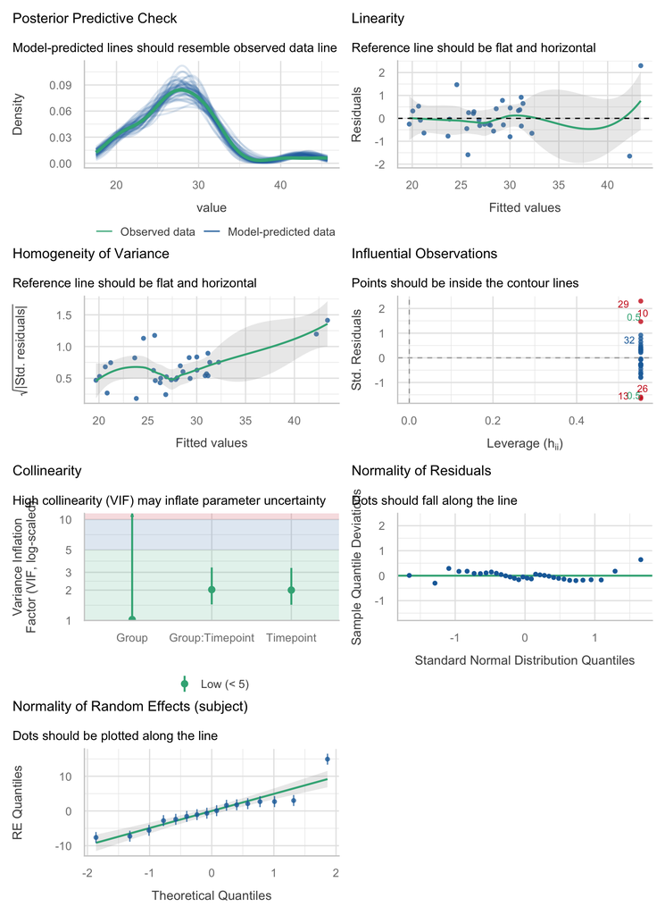

Figure 1. check_model assumptions for the mCSA model.

```r
check_model(fits[["mCSA"]], verbose = FALSE)
```

Residuals track the reference lines and the random intercepts are near-normal. Two panels need context at this design, below.

### Reading two panels

**Homogeneity of variance.** For the CSA outcomes the line slopes up: residual spread grows with fitted size, as area measures tend to. The effect is mild and the result is robust — a log transform removes most of it and the divergence interaction only strengthens (mCSA p 0.038 → 0.008; every fibre outcome stays p < 0.002). The raw models are kept because they are interpretable in native units and match the split-plot ANOVA.

**Influential observations.** A balanced 2×2 design gives every observation the same leverage (0.553 here), so `check_model`’s leverage view cannot separate influential points and its flagged IDs are an artifact, not a warning. The meaningful check is a leave-one-subject refit: how far the divergence coefficient moves when each subject is dropped, against the 2/√n DFBETAS guide.

```r
kable(lmm_loso_influence(meta),
  digits = 3,
  caption = "Leave-one-subject influence on the divergence coefficient"
)
```

Leave-one-subject influence on the divergence coefficient

| measure | max_abs_shift | dfbetas_guide |
| --- | --- | --- |
| mCSA | 0.103 | 0.5 |
| fCSA Mixed | 0.185 | 0.5 |
| fCSA Type I | 0.194 | 0.5 |
| fCSA Type II | 0.144 | 0.5 |
| 1RM Leg Press | 0.130 | 0.5 |
| 1RM Extension | 0.080 | 0.5 |

No subject shifts any coefficient past 0.19, well inside the 0.5 guide: the divergence rests on no single subject.

## Key terms

**Group × Timepoint interaction** — the divergence test: different change in HR vs LR from T1 to T2.

**Change advantage** — the interaction contrast in raw units, HR minus LR.

**ICC** — intraclass correlation, the between-subject share of variance. High ICC means subjects differ from each other more than the intervention moves them.

**Marginal vs conditional R²** — fixed-effect variance vs fixed plus random; a wide gap signals between-subject dominance.

**Satterthwaite df** — a small-sample degrees-of-freedom correction; treating t as z inflates false positives at n = 16.

**Holm adjustment** — a multiple-testing correction across the six contrasts.